# Assignment-3

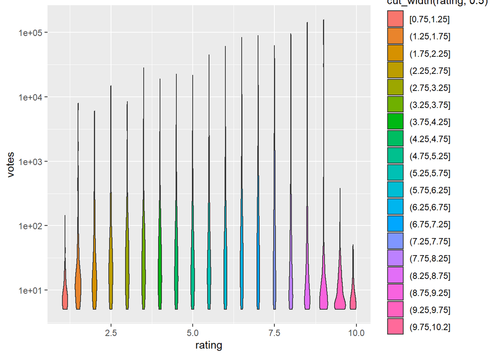

```r
ggplot(data = m) +geom_violin(mapping=aes(rating,votes, fill= cut_width(rating,0.5)))+ scale_y_log10()
```

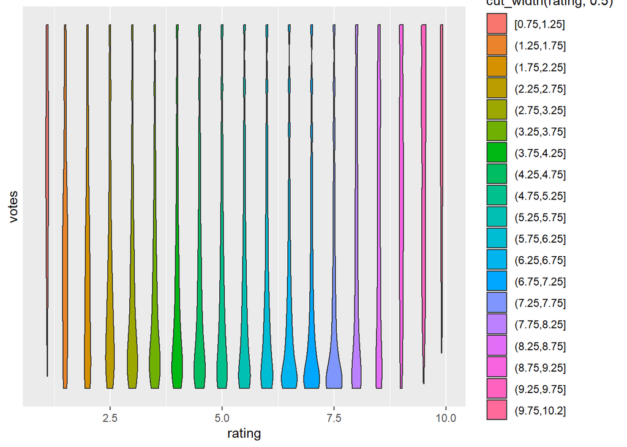

```r
ggplot(data = m) +geom_violin(mapping=aes(rating,votes, fill= cut_width(rating,0.5)))+ scale_y_continuous(trans = "reciprocal")
```

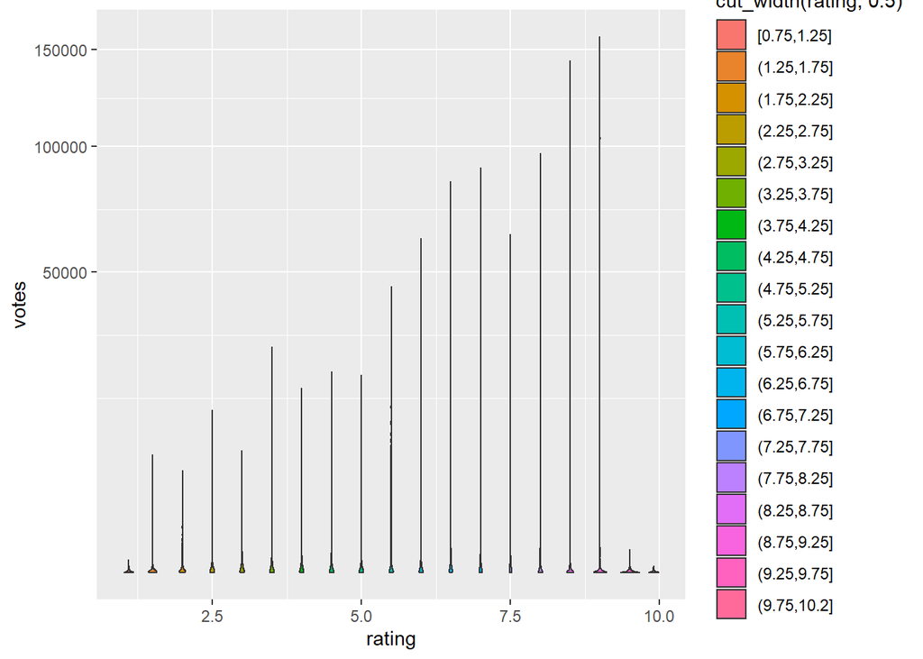

```r
ggplot(data = m) +geom_violin(mapping=aes(rating,votes, fill= cut_width(rating,0.5)))+ scale_y_sqrt()
```

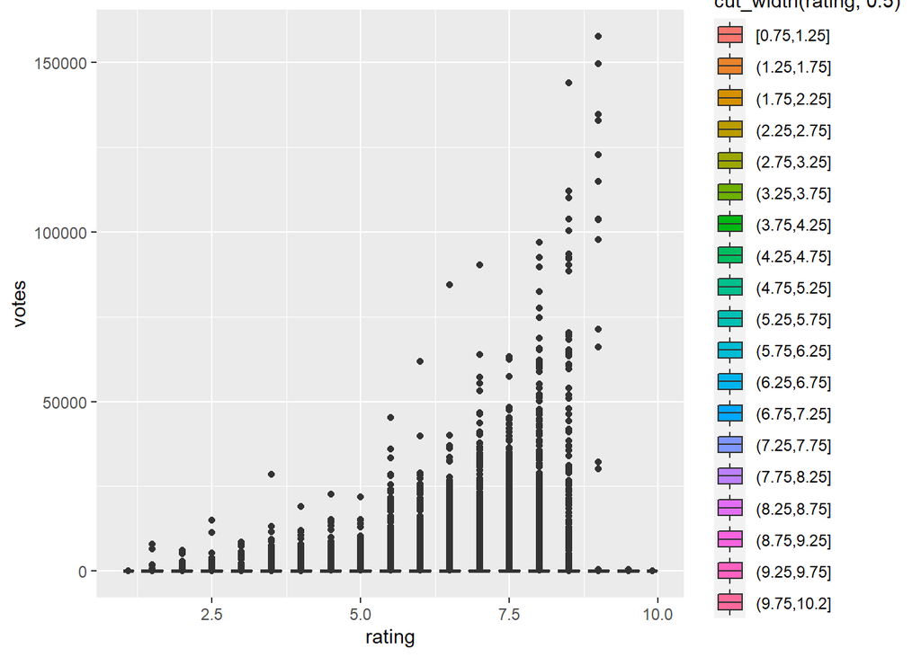

```r
ggplot(data = m) +geom_boxplot(mapping=aes(rating,votes, fill= cut_width(rating,0.5)),scale = "area")
```

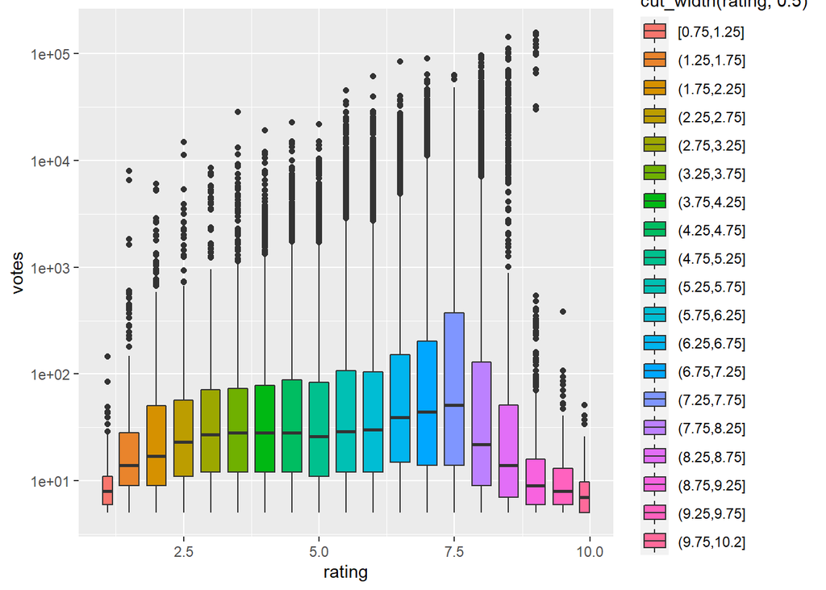

```r
ggplot(data = m) +geom_boxplot(mapping=aes(rating,votes, fill= cut_width(rating,0.5)))+ scale_y_log10()
```

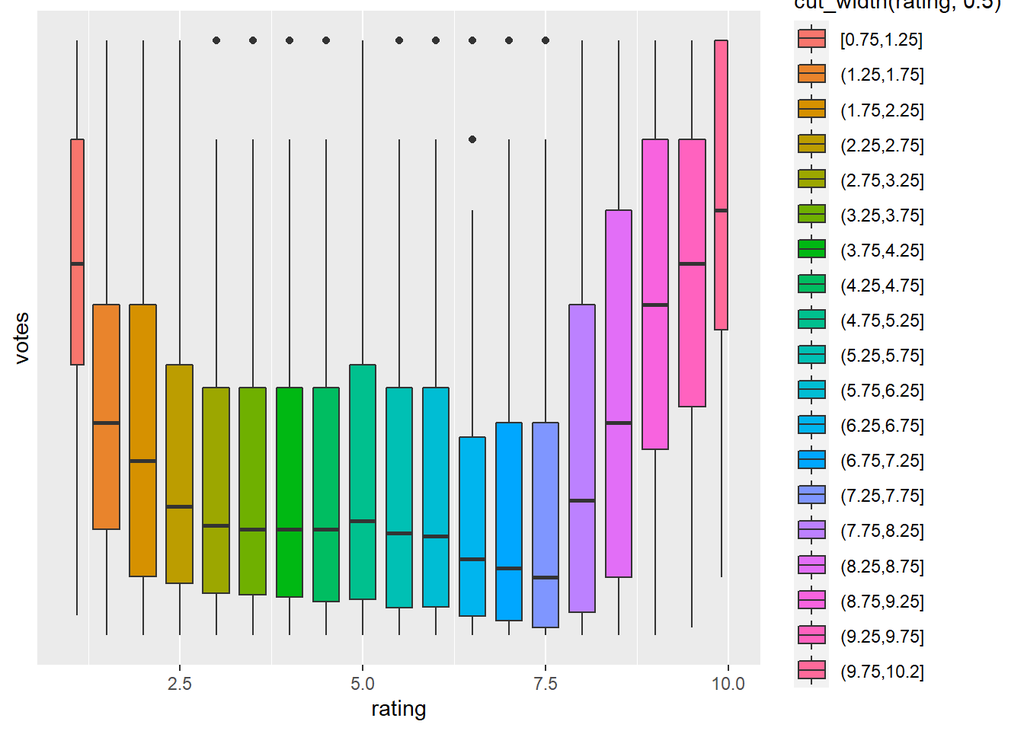

```r
ggplot(data = m) +geom_boxplot(mapping=aes(rating,votes,fill= cut_width(rating,0.5)))+ scale_y_continuous(trans = "reciprocal")
```

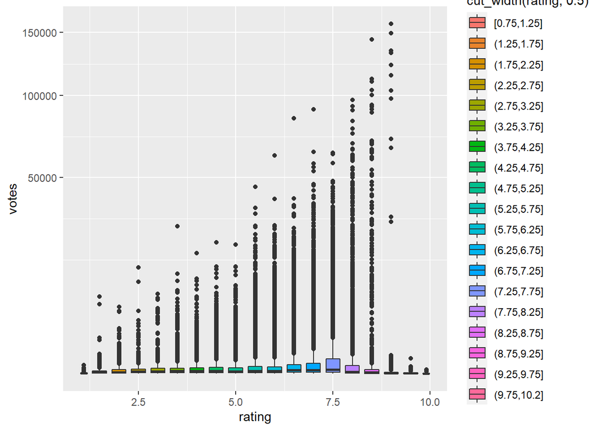

```r
ggplot(data = m) +geom_boxplot(mapping=aes(rating,votes, fill= cut_width(rating,0.5)))+ scale_y_sqrt()
```

14. Attempt to plot an area plot (geom_area) with the column votes in movies dataset. Notice the extreme skewness of the data. Experiment with various ranges for the votes column in order to get a meaningful plot (say xlim between 0 and 200). Also attempt to use a transformed value of x (votes) using log10, i.e. using scale_x_continuous(trans=“log10”).

```r
library("ggplot2movies")
m <- movies;head(m)
```

```
## # A tibble: 6 × 24
##   title      year length budget rating votes    r1    r2    r3    r4    r5    r6
##   <chr>     <int>  <int>  <int>  <dbl> <int> <dbl> <dbl> <dbl> <dbl> <dbl> <dbl>
## 1 $          1971    121     NA    6.4   348   4.5   4.5   4.5   4.5  14.5  24.5
## 2 $1000 a …  1939     71     NA    6      20   0    14.5   4.5  24.5  14.5  14.5
## 3 $21 a Da…  1941      7     NA    8.2     5   0     0     0     0     0    24.5
## 4 $40,000    1996     70     NA    8.2     6  14.5   0     0     0     0     0
## 5 $50,000 …  1975     71     NA    3.4    17  24.5   4.5   0    14.5  14.5   4.5
## 6 $pent      2000     91     NA    4.3    45   4.5   4.5   4.5  14.5  14.5  14.5
## # … with 12 more variables: r7 <dbl>, r8 <dbl>, r9 <dbl>, r10 <dbl>,
## #   mpaa <chr>, Action <int>, Animation <int>, Comedy <int>, Drama <int>,
## #   Documentary <int>, Romance <int>, Short <int>
```

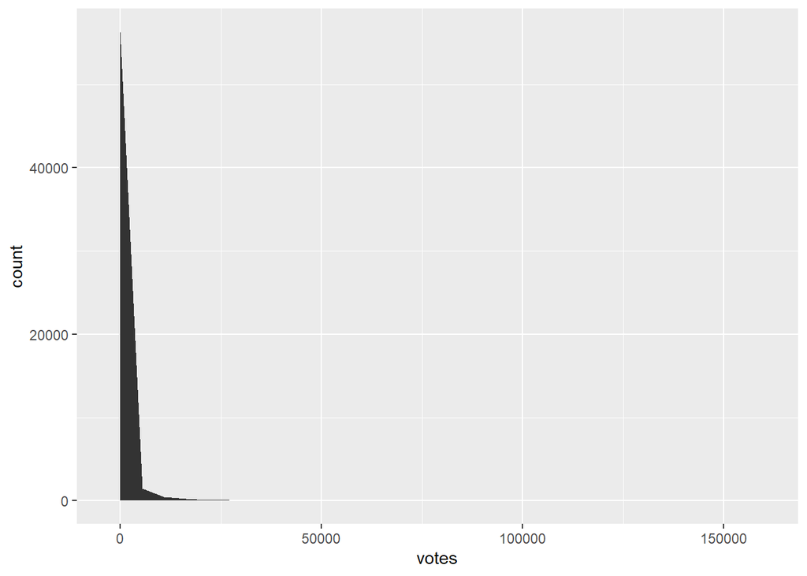

```r
ggplot(data=m, aes(votes)) + geom_area(stat = "bin")
```

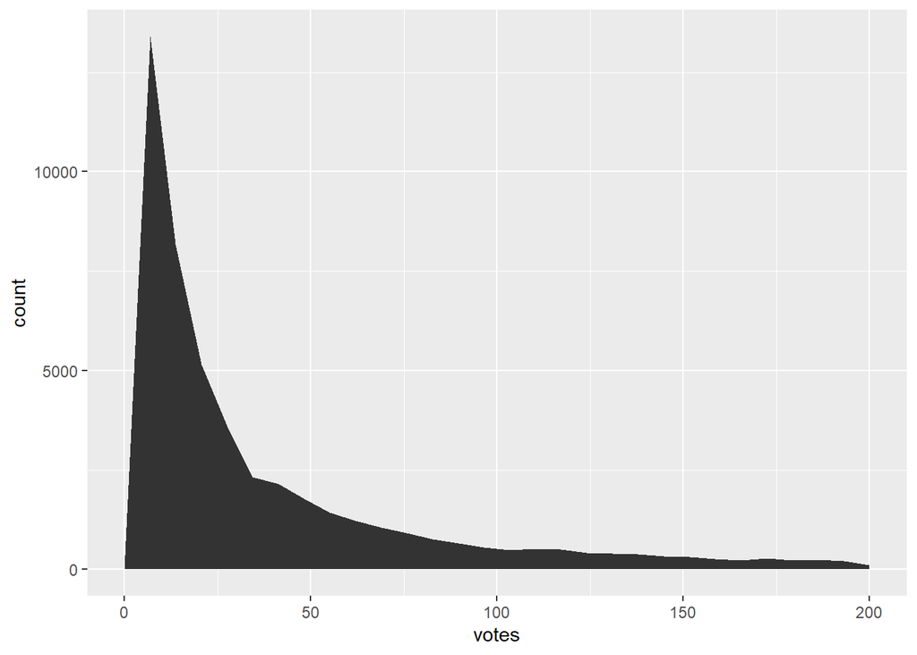

```r
ggplot(data=m, aes(votes)) + geom_area(stat = "bin") + xlim(0,200)
```

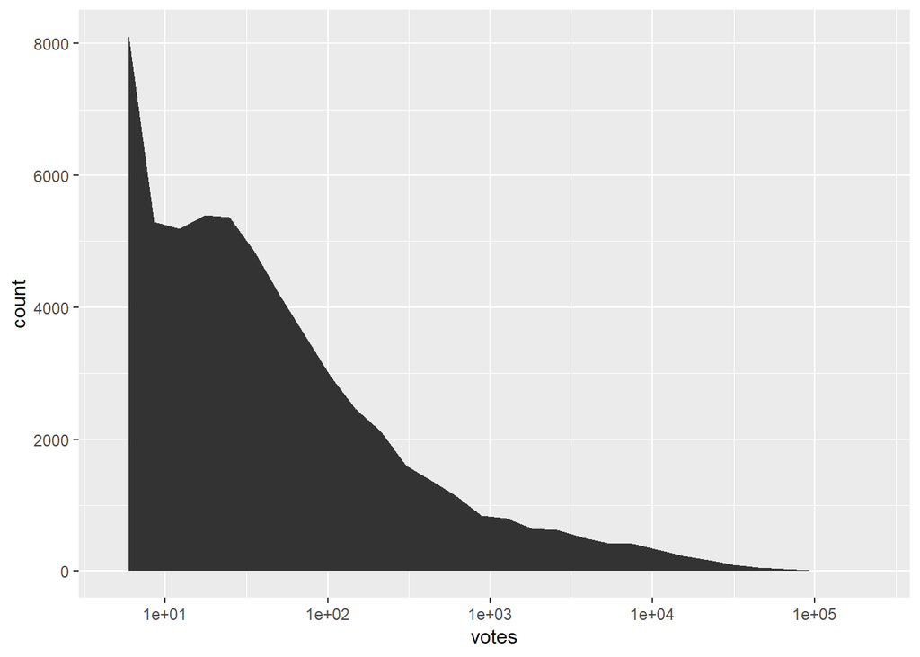

```r
ggplot(data=m, aes(votes)) + geom_area(stat = "bin") + scale_x_continuous(trans = "log10")
```

15. Attempt a scatter plot of mpg dataset using geom_jitter and the cty and hwy columns. Modify the plot by customising your x axis labels and x axis ticks and shape based on a categorical columns. Customise the legend using the theme function.

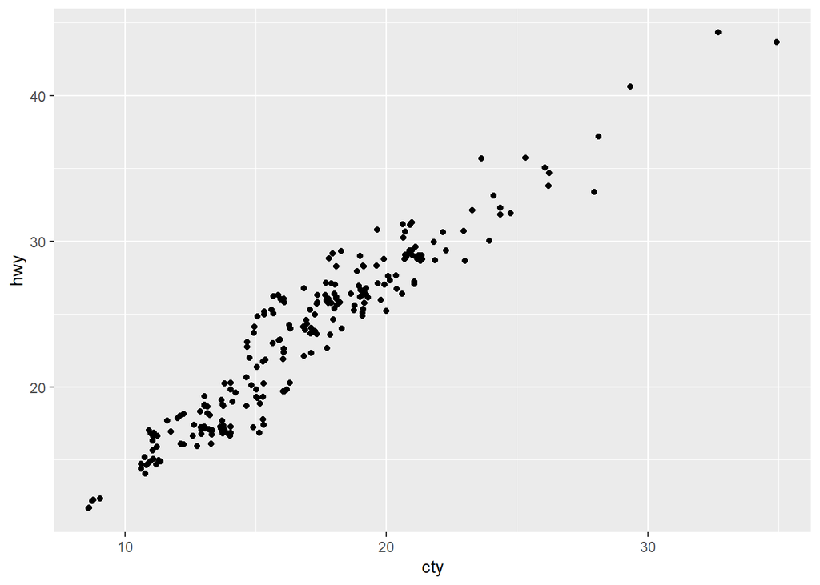

```r
ggplot(mpg,aes())+
  geom_jitter(aes(x=cty,y=hwy))
```

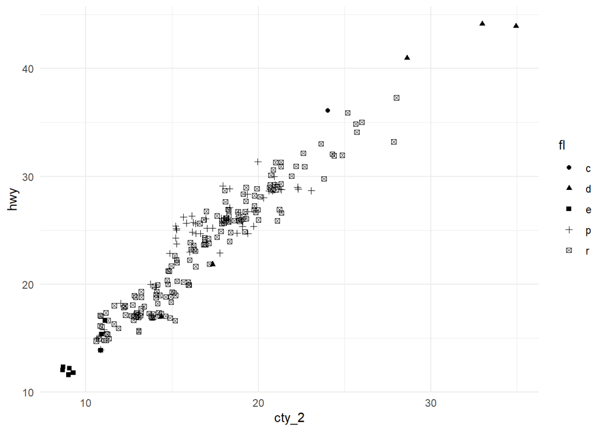

```r
ggplot(mpg,aes())+
  geom_jitter(aes(x=cty,y=hwy, shape = fl)) +
  labs(x="cty_2") +
  theme_minimal()
```